# Chapter 5 Supplement

# Model exploration: comparison with compartment models and original data

```r
library(tidyverse)
library(ggforce)
```

Loading data for trials of ABM V1:

```r
#Initial results
modelV1_experiments1 <- read.csv("data/full model run.csv",skip = 25)
#Coercion
colnames(modelV1_experiments1)[1] <- "day"
modelV1_experiments1$day <- 1:dim(modelV1_experiments1)[1]
modelV1_experiments1 <- modelV1_experiments1 %>%
  pivot_longer(2:41) %>%
  mutate(experiment = substr(name,start =nchar(name),stop=nchar(name))) %>%
  mutate(experiment = if_else(experiment == "s"|experiment == ".",1,as.integer(experiment)+1)) %>%
  mutate(experiment = as.factor(experiment)) %>%
  mutate(series = str_extract(name,"with..\\w+")) %>%
  mutate(series = if_else(is.na(series),"notifications",substr(series,start=7,stop=nchar(series)))) %>%
  mutate(series = factor(series,levels = c("notifications","susceptible","exposed","infectious","removed"))) %>%
  mutate(value = value*7842545/27381)
```

Trial compartment graphs:

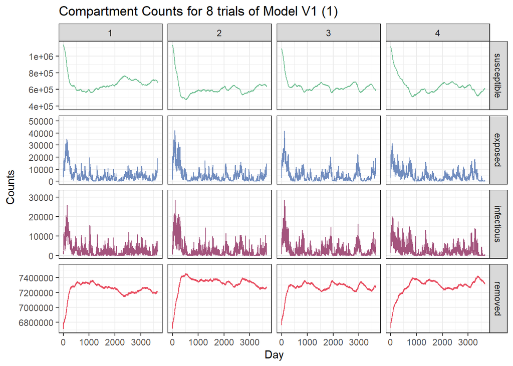

```r
modelV1_experiments1 %>%
  filter(series != "notifications") %>%
  ggplot() +
  geom_line(aes(x = day,y=value,color = series)) +
  facet_grid_paginate(series~experiment,scales = "free",ncol = 4,nrow = 4,page = 1) +
  theme_bw() +
  labs(title = "Compartment Counts for 8 trials of Model V1 (1)",x = "Day",y = "Counts") +
  scale_color_manual(values = c("#77c298","#718dbf","#a4547d","#e84d60")) +
  guides(colour = "none")
```

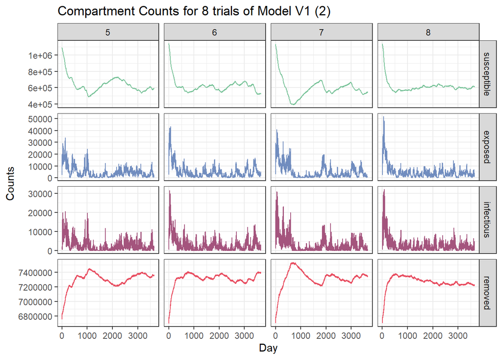

```r
modelV1_experiments1 %>%
  filter(series != "notifications") %>%
  ggplot() +
  geom_line(aes(x = day,y=value,color = series)) +
  facet_grid_paginate(series~experiment,scales = "free",ncol = 4,nrow = 4,page = 2) +
  theme_bw() +
  labs(title = "Compartment Counts for 8 trials of Model V1 (2)",x = "Day",y = "Counts") +
  scale_color_manual(values = c("#77c298","#718dbf","#a4547d","#e84d60")) +
  guides(colour = "none")
```

Loading and displaying data showing the presence of local outbreaks:

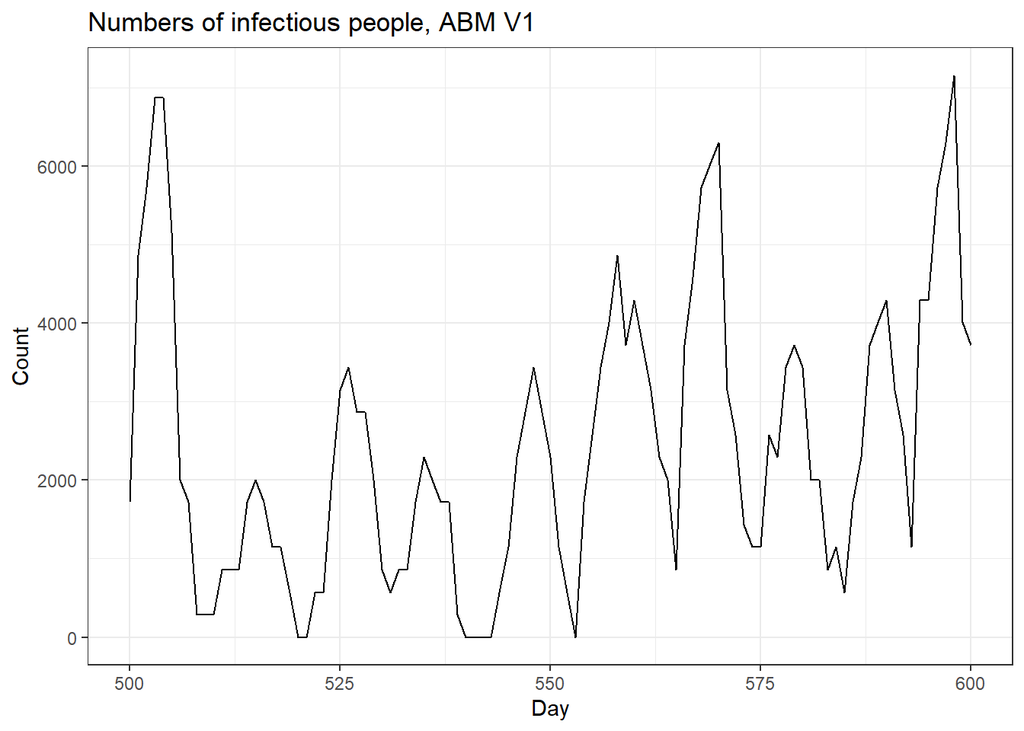

```r
outbreak_compartment_counts <- read.csv("data/full_model_run07042021 Compartment Counts.csv",
    skip = 17)
outbreak_compartment_counts <- outbreak_compartment_counts %>%
  select(x,y,y.1) %>%
  transmute(day = x,exposed = y,infectious = y.1) %>%
  pivot_longer(2:3) %>%
  mutate(value = value*7842545/27381)

outbreak_compartment_counts %>%
  filter(day >= 500, day <= 600,name == "infectious") %>%
  ggplot() +
  geom_line(aes(x = day,y = value)) +
  theme_bw() +
  labs(title = "Numbers of infectious people, ABM V1",x = "Day",y = "Count")
```

Simulation trial with introduction algorithm disabled:

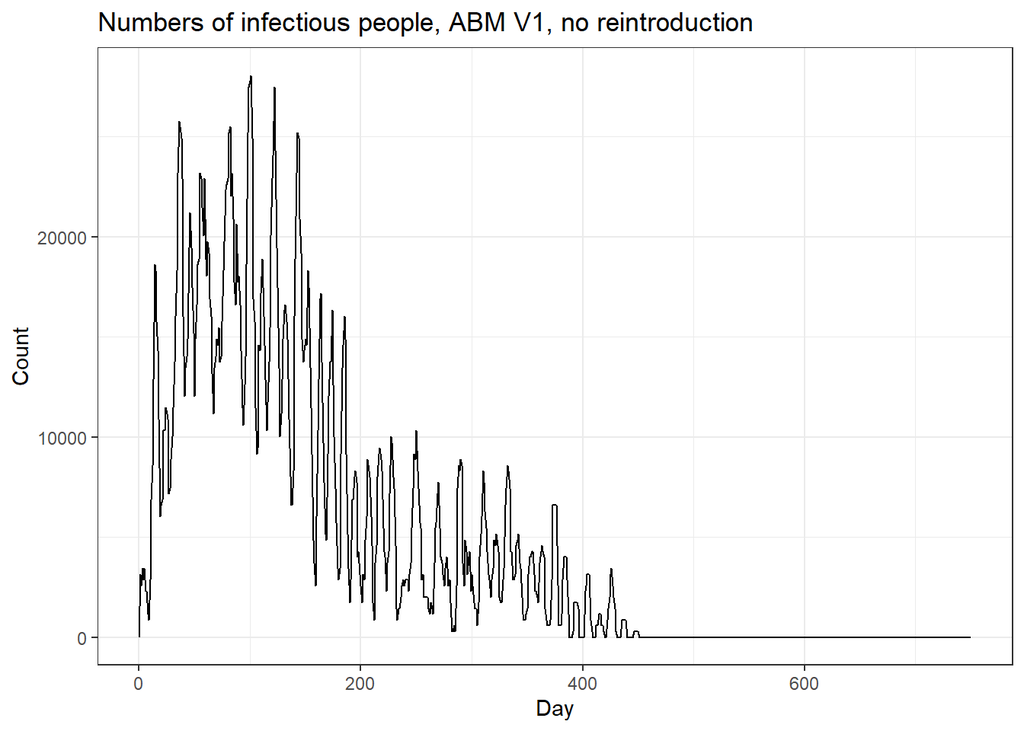

```r
no_reintroduction_compartment_counts <- read.csv("data/full_model_run07042021 Compartment Counts no reintroduction.csv",
    skip = 17)
no_reintroduction_compartment_counts <- no_reintroduction_compartment_counts %>%
  select(x,y,y.1) %>%
  transmute(day = x,exposed = y,infectious = y.1) %>%
  pivot_longer(2:3) %>%
  mutate(value = value*7842545/27381)

no_reintroduction_compartment_counts %>%
  filter(name == "infectious") %>%
  ggplot() +
  geom_line(aes(x = day,y = value)) +
  theme_bw() +
  labs(title = "Numbers of infectious people, ABM V1, no reintroduction",y = "Count",x = "Day") +
  xlim(c(0,750))
```

Comparison with New York Data:

```r
SEIR_soln_df <- read.csv("data/SEIR_soln.csv")
SEIR_soln_df %>%
  mutate(time = floor(time*365)) %>%
  select(-X) -> SEIR_soln_df
colnames(SEIR_soln_df) <- c("day","susceptible","exposed","infectious","removed","N")
SEIR_soln_df %>%
  pivot_longer(2:6) %>%
  mutate(name = factor(name,levels = c("notifications","susceptible","exposed","infectious","removed","N"))) -> SEIR_soln_df

colnames(SEIR_soln_df) <- c("day","series","value")
SEIR_soln_df <- SEIR_soln_df %>%
  mutate(model = "SEIR equations")

new_york_measles <- read.csv("data/new_york_measlescsv.csv") %>%
  filter(numdate >= 1950, numdate <= 1960)

new_york_year_avg <- read.csv("data/new_york_year_avg.csv")

modelV1_experiments1_summary <- modelV1_experiments1 %>%
  filter(series != "notifications") %>%
  group_by(day,series) %>%
  summarise(value = mean(value)) %>%
  mutate(model = "ABM")
```

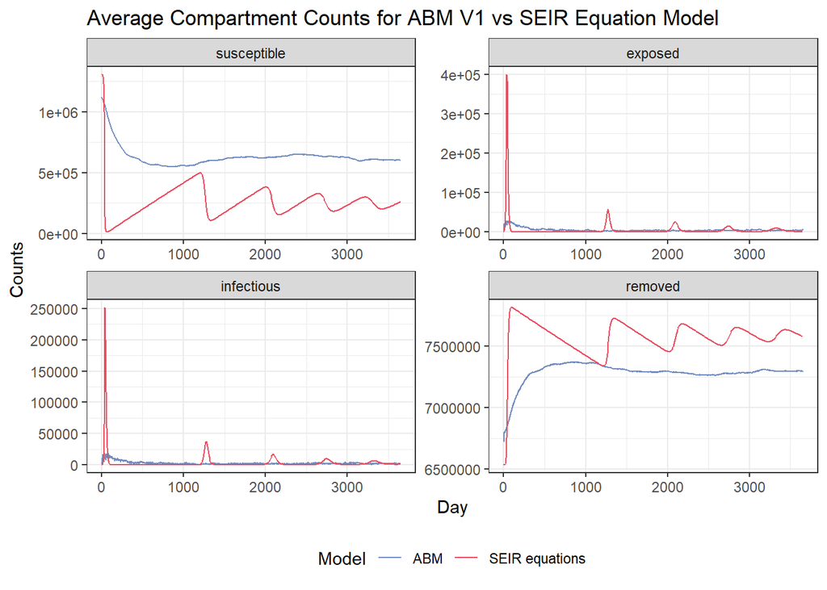

```r
modelV1_SEIR <- rbind(modelV1_experiments1_summary,SEIR_soln_df)

# modelV1_SEIR <- rbind(modelV1_experiments1_summary,modelV1_experiments3_summary,SEIR_soln_df)

modelV1_SEIR %>%
  filter(series != "N", series!= "Notifications") %>%
  ggplot() +
  geom_line(aes(x= day,y = value,colour = model)) +
  facet_wrap(.~series,scales = "free") +
  theme_bw() +
  labs(title = "Average Compartment Counts for ABM V1 vs SEIR Equation Model",x = "Day",y = "Counts") +
  scale_color_manual(values =c("#718dbf","#e84d60"),name = "Model") +
  theme(legend.position = "bottom")
```

Estimating equilibrium point from the simulation trials:

```r
ABM_eqs <- modelV1_experiments1 %>%
  filter(day >= 3*365) %>%
  group_by(series,experiment) %>%
  summarise(eq = mean(value))
ABM_eq_est <- ABM_eqs %>%
                 group_by(series) %>%
                 summarise(mean_eq = mean(eq),var_eq = var(eq))

ABM_eq_est
```

| series | mean_eq | var_eq |
| --- | --- | --- |
| notifications | 399.0682 | 4.942206e+02 |
| susceptible | 619139.0077 | 6.158594e+08 |
| exposed | 3568.7765 | 3.960961e+04 |
| infectious | 1987.9479 | 1.240506e+04 |
| removed | 7295378.0452 | 1.112706e+09 |

Confidence interval for equilibrium from simulation trials:

```r
eq_confint <- ABM_eq_est %>%
  mutate(pm = qt(0.95,7)*sqrt(var_eq/8)) %>%
  mutate(lower_confint = mean_eq - pm, upper_confint = mean_eq + pm) %>%
  select(-mean_eq,-var_eq,-pm)

eq_confint
```

| series | lower_confint | upper_confint |
| --- | --- | --- |
| notifications | 384.177 | 413.9593 |
| susceptible | 602516.046 | 635761.9698 |
| exposed | 3435.465 | 3702.0881 |
| infectious | 1913.343 | 2062.5527 |
| removed | 7273034.208 | 7317721.8827 |

SEIR equation equilibria:

```r
N <- 7842545
mu <- 0.02096239
sigma <- 1/(9/365)
gamma <- 1/(5/365)
beta <- 0.0002715625

predicted_eq <- c((mu + gamma)*(mu + sigma)/(beta * sigma),
                  mu*(N/(mu + sigma) - (mu + gamma)/(beta * sigma)),
                  mu*((sigma*N)/((mu + gamma)*(mu + sigma))-1/beta),
                gamma*((sigma*N)/((mu + gamma)*(mu + sigma)))-1/beta)

predicted_eq
```

```
## [1]  269030.906    3912.582    2173.033 7832560.815
```

```r
modelV1_radii <- read.csv("data/full_model_run07042021 restriction variations.csv",skip = 25)
#Coercion
colnames(modelV1_radii)[1] <- "day"
modelV1_radii$day <- 1:dim(modelV1_radii)[1]
modelV1_radii <- modelV1_radii %>%
  pivot_longer(2:41) %>%
  mutate(experiment = substr(name,start =nchar(name),stop=nchar(name))) %>%
  mutate(experiment = if_else(experiment == "s"|experiment == ".",1,as.integer(experiment)+1)) %>%
  mutate(experiment = as.factor(experiment)) %>%
  mutate(series = str_extract(name,"with..\\w+")) %>%
  mutate(series = if_else(is.na(series),"notifications",substr(series,start=7,stop=nchar(series)))) %>%
  mutate(series = factor(series,levels = c("notifications","susceptible","exposed","infectious","removed")))%>%
  mutate(value = value*7842545/27381)
```

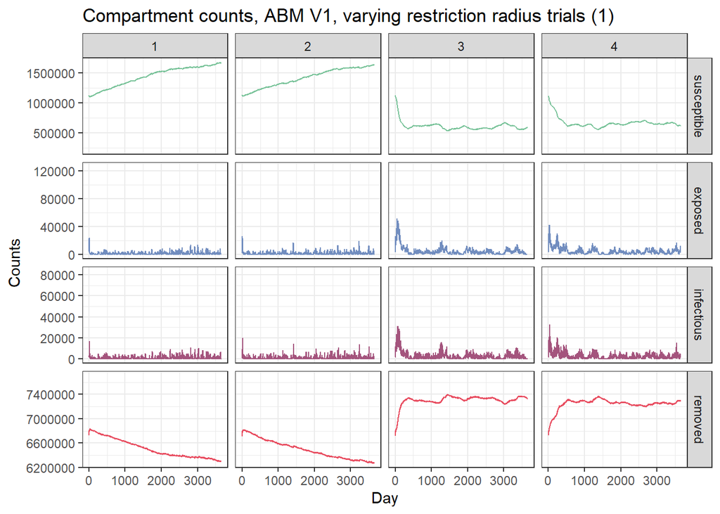

```r
modelV1_radii %>%
  filter(series != "notifications") %>%
  ggplot() +
  geom_line(aes(x = day,y=value,color = series)) +
  facet_grid_paginate(series~experiment,scales = "free",ncol = 4,nrow = 4,page = 1) +
  theme_bw() +
  labs(title = "Compartment counts, ABM V1, varying restriction radius trials (1)",x = "Day",y = "Counts") +
  scale_color_manual(values = c("#77c298","#718dbf","#a4547d","#e84d60")) +
  guides(colour = "none")
```

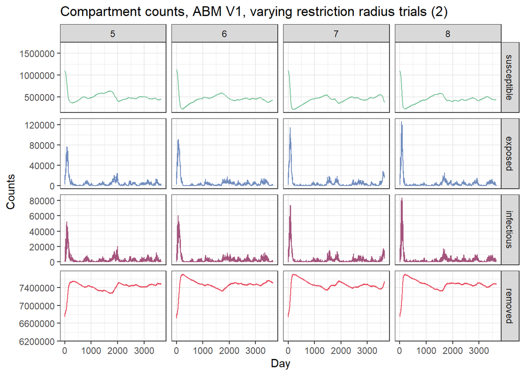

```r
modelV1_radii %>%
  filter(series != "notifications") %>%
  ggplot() +
  geom_line(aes(x = day,y=value,color = series)) +
  facet_grid_paginate(series~experiment,scales = "free",ncol = 4,nrow = 4,page = 2) +
  theme_bw() +
  labs(title = "Compartment counts, ABM V1, varying restriction radius trials (2)",x = "Day",y = "Counts") +
  scale_color_manual(values = c("#77c298","#718dbf","#a4547d","#e84d60")) +
  guides(colour = "none")
```

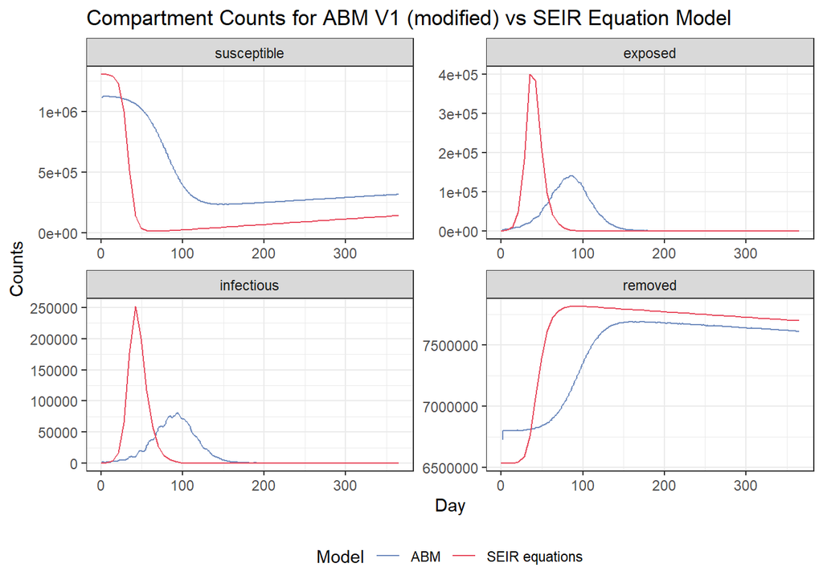

```r
modelV1_unrestricted_movement <- read.csv("data/full_model_run07042021 plots unrestricted movement.csv",skip = 25)
#Coercion
colnames(modelV1_unrestricted_movement)[1] <- "day"
modelV1_unrestricted_movement$day <- 1:dim(modelV1_unrestricted_movement)[1]
modelV1_unrestricted_movement <- modelV1_unrestricted_movement %>%
  pivot_longer(2:41) %>%
  mutate(experiment = substr(name,start =nchar(name),stop=nchar(name))) %>%
  mutate(experiment = if_else(experiment == "s"|experiment == ".",1,as.integer(experiment)+1)) %>%
  mutate(experiment = as.factor(experiment)) %>%
  mutate(series = str_extract(name,"with..\\w+")) %>%
  mutate(series = if_else(is.na(series),"notifications",substr(series,start=7,stop=nchar(series)))) %>%
  mutate(series = factor(series,levels = c("notifications","susceptible","exposed","infectious","removed")))%>%
  mutate(value = value*7842545/27381)
modelV1_unrestricted_movement_summary <- modelV1_unrestricted_movement %>%
  filter(series != "notifications") %>%
  group_by(day,series) %>%
  summarise(value = mean(value)) %>%
  mutate(model = "ABM")
modelV1_SEIR <- rbind(modelV1_unrestricted_movement_summary,SEIR_soln_df)

# modelV1_SEIR <- rbind(modelV1_experiments1_summary,modelV1_experiments3_summary,SEIR_soln_df)

modelV1_SEIR %>%
  filter(series != "N", series!= "Notifications") %>%
  ggplot() +
  geom_line(aes(x= day,y = value,colour = model)) +
  facet_wrap(.~series,scales = "free") +
  theme_bw() +
  labs(title = "Compartment Counts for ABM V1 (modified) vs SEIR Equation Model",x = "Day",y = "Counts") +
  scale_color_manual(values =c("#718dbf","#e84d60"),name = "Model") +
  theme(legend.position = "bottom") +
  xlim(c(0,365))
```

Plot of notification weekly totals:

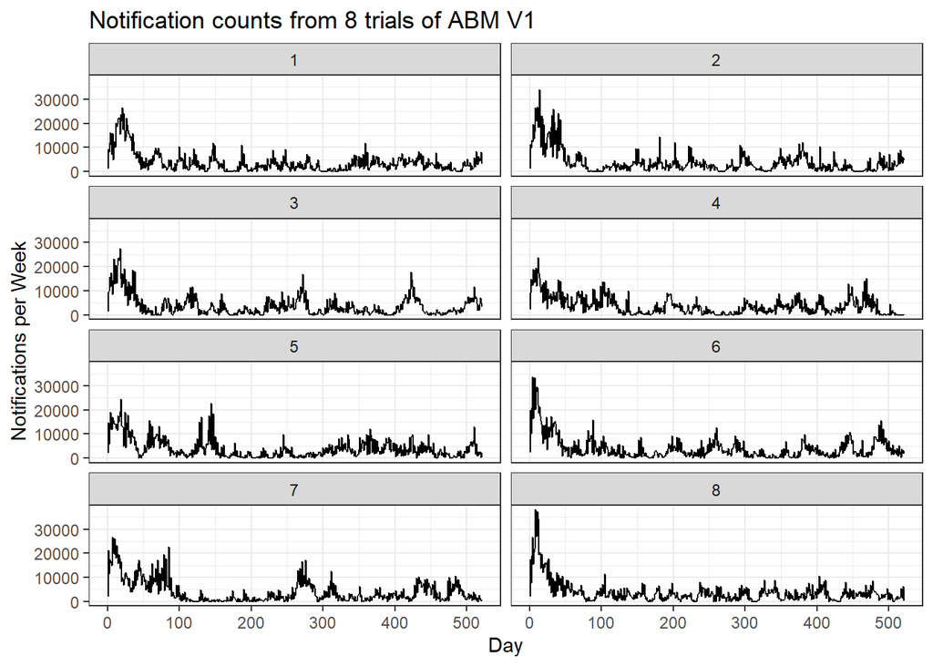

```r
modelV1_experiments1 %>%
  filter(series == "notifications") %>%
  mutate(week = floor(day/7)) %>%
  group_by(experiment,week) %>%
  summarise(weekly_notifications = sum(value)) %>%
  ggplot() +
  geom_line(aes(x = week,y=weekly_notifications)) +
  facet_wrap(.~experiment,ncol = 2) +
  theme_bw() +
  labs(title = "Notification counts from 8 trials of ABM V1",x = "Day",y = "Notifications per Week") +
  scale_linetype_discrete(name = "") +
  guides(colour = "none")
```

Comparison of experiment 1 with original data:

```r
modelV1_experiments1_notifications_summary <- modelV1_experiments1 %>%
  filter(series == "notifications") %>%
  mutate(week = floor(day/7)) %>%
  group_by(experiment,week) %>%
  summarise(weekly_notifications = sum(value))
```

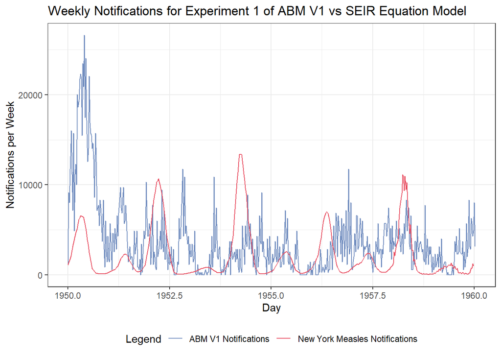

```r
modelV1_experiments1_notifications_summary %>%
  filter(experiment == "1") %>%
  ggplot() +
  geom_line(aes(x = week/52+1950,y= weekly_notifications,colour = "ABM V1 Notifications")) +
  geom_line(data = new_york_measles,aes(x = numdate,y = cases/0.167,colour = "New York Measles Notifications")) +
  scale_color_manual(values = c("#718dbf","#e84d60"),name = "Legend") +
  labs(title = "Weekly Notifications for Experiment 1 of ABM V1 vs SEIR Equation Model",x = "Day",y = "Notifications per Week") +
  theme_bw() +
  theme(legend.position = "bottom")
```

Average weekly notifications for ABM vs observed:

```r
avg_weekly_notifications_ABM <- mean(filter(modelV1_experiments1_notifications_summary,week >52)$weekly_notifications)
avg_weekly_notifications <- mean(new_york_measles$cases/0.167)
avg_weekly_notifications_ABM
```

```
## [1] 2984.31
```

```r
avg_weekly_notifications
```

```
## [1] 2148.9
```

# Revising the latent and infectious period submodel

Loading experiment results for ABM V2:

```r
modelV2_experiments1 <- read.csv("data/stochastic periods demonstration-spreadsheet.csv",skip = 27)
#Coercion
colnames(modelV2_experiments1)[1] <- "day"
modelV2_experiments1$day <- 1:dim(modelV2_experiments1)[1]
modelV2_experiments1 <- modelV2_experiments1 %>%
  pivot_longer(2:41) %>%
  mutate(experiment = substr(name,start =nchar(name),stop=nchar(name))) %>%
  mutate(experiment = if_else(experiment == "s"|experiment == ".",1,as.integer(experiment)+1)) %>%
  mutate(experiment = as.factor(experiment)) %>%
  mutate(series = str_extract(name,"with..\\w+")) %>%
  mutate(series = if_else(is.na(series),"notifications",substr(series,start=7,stop=nchar(series)))) %>%
  mutate(series = factor(series,levels = c("notifications","susceptible","exposed","infectious","removed"))) %>%
  mutate(value = value*7842545/27381)
```

Graph of experiment results for ABM V2:

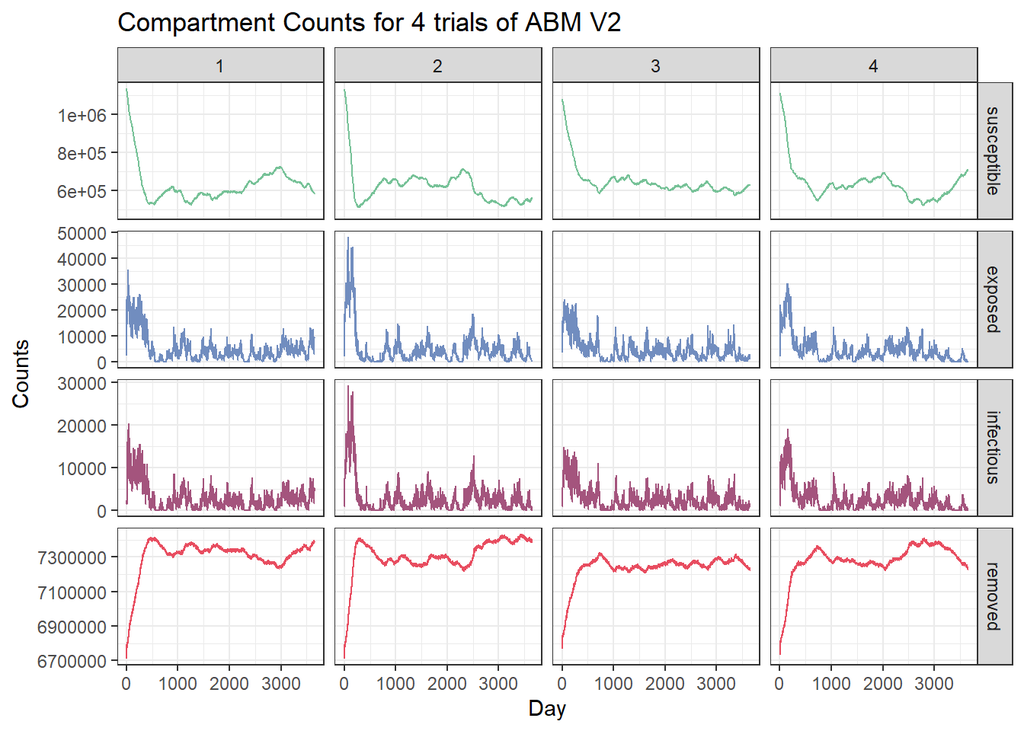

```r
modelV2_experiments1 %>%
  filter(series != "notifications") %>%
  ggplot() +
  geom_line(aes(x = day,y=value,color = series)) +
  facet_grid_paginate(series~experiment,scales = "free",ncol = 4,nrow = 4,page = 1) +
  theme_bw() +
  labs(title = "Compartment Counts for 4 trials of ABM V2",x = "Day",y = "Counts") +
  scale_color_manual(values = c("#77c298","#718dbf","#a4547d","#e84d60")) +
  guides(colour = "none")
```

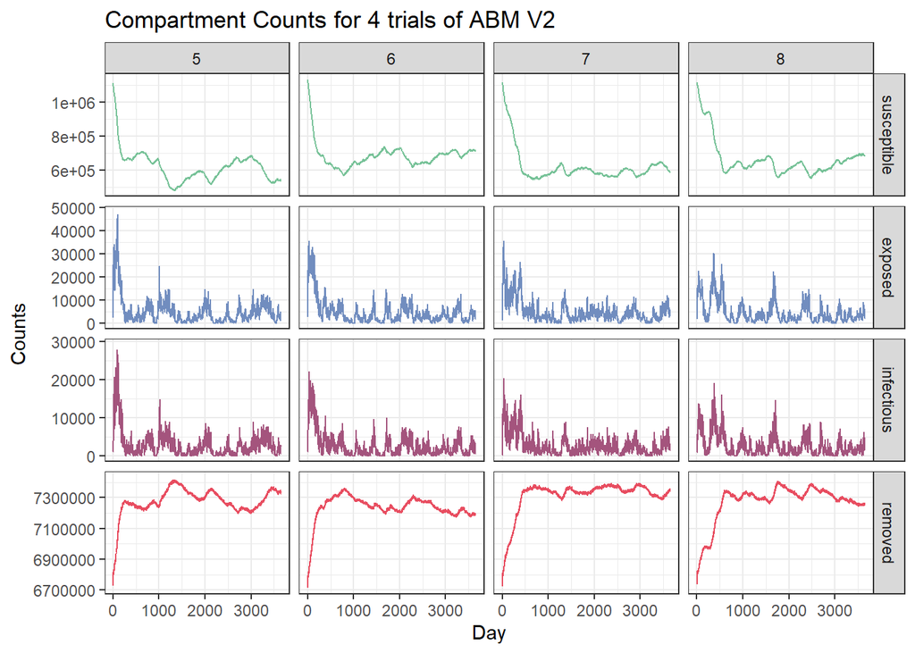

```r
modelV2_experiments1 %>%
  filter(series != "notifications") %>%
  ggplot() +
  geom_line(aes(x = day,y=value,color = series)) +
  facet_grid_paginate(series~experiment,scales = "free",ncol = 4,nrow = 4,page = 2) +
  theme_bw() +
  labs(title = "Compartment Counts for 4 trials of ABM V2",x = "Day",y = "Counts") +
  scale_color_manual(values = c("#77c298","#718dbf","#a4547d","#e84d60")) +
  guides(colour = "none")
```

Comparison of results of ABM V1 to ABM V2:

```r
modelV1_experiments1_summary <- modelV1_experiments1 %>%
  filter(series != "notifications") %>%
  group_by(day,series) %>%
  summarise(value = mean(value)) %>%
  mutate(model = "ABM V1")
modelV2_experiments1_summary <- modelV2_experiments1 %>%
  filter(series != "notifications") %>%
  group_by(day,series) %>%
  summarise(value = mean(value)) %>%
  mutate(model = "ABM V2")
```

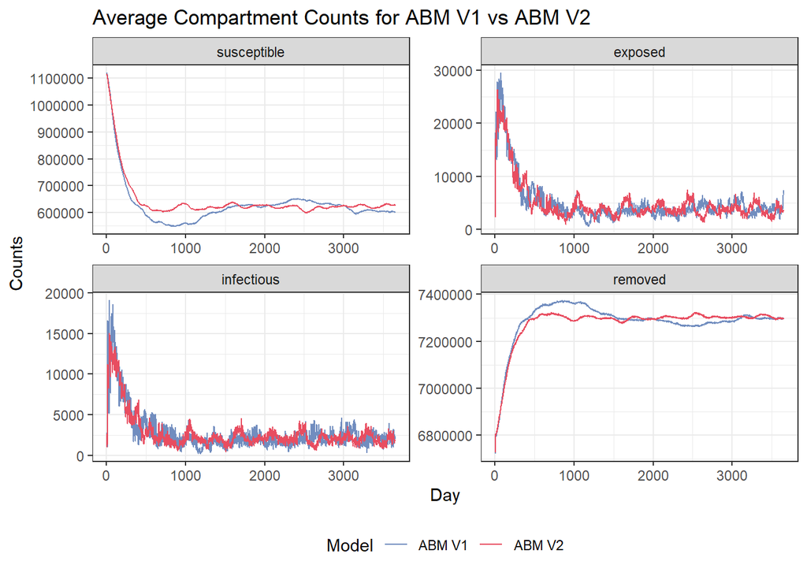

```r
modelV1_SEIR <- rbind(modelV1_experiments1_summary,modelV2_experiments1_summary)

# modelV1_SEIR <- rbind(modelV1_experiments1_summary,modelV1_experiments3_summary,SEIR_soln_df)

modelV1_SEIR %>%
  filter(series != "N", series!= "Notifications") %>%
  ggplot() +
  geom_line(aes(x= day,y = value,colour = model)) +
  facet_wrap(.~series,scales = "free") +
  theme_bw() +
  labs(title = "Average Compartment Counts for ABM V1 vs ABM V2",x = "Day",y = "Counts") +
  scale_color_manual(values =c("#718dbf","#e84d60"),name = "Model") +
  theme(legend.position = "bottom")
```

# Implementing Seasonal Variation

Loading ABM V3A data:

```r
ABM_V3A_experiments <- read.csv("data/model08042021_seasonal_variationv3A movement submodel.csv",
    skip = 33)
ABM_V3A_experiments[[1]] <- 1:dim(ABM_V3A_experiments)[1]
colnames(ABM_V3A_experiments)[1] <- "day"
ABM_V3A_experiments <- ABM_V3A_experiments %>%
  pivot_longer(2:dim(ABM_V3A_experiments)[2]) %>%
  mutate(experiment = str_extract(name,"\\d+$")) %>%
  mutate(experiment = if_else(is.na(experiment),1,as.integer(experiment)+1)) %>%
  mutate(series = str_extract(name,"with..\\w+")) %>%
  mutate(series = if_else(is.na(series),"notifications",substr(series,start=7,stop=nchar(series)))) %>%
  mutate(series = factor(series,levels = c("notifications","susceptible","exposed","infectious","removed"))) %>%
  mutate(value = value*7842545/27382)

ABM_V3A_experiments <- ABM_V3A_experiments %>%
  filter(series != "notifications" | (series == "notifications" & day %% 7 == 1))
```

Graphs of ABM v3A compartment counts:

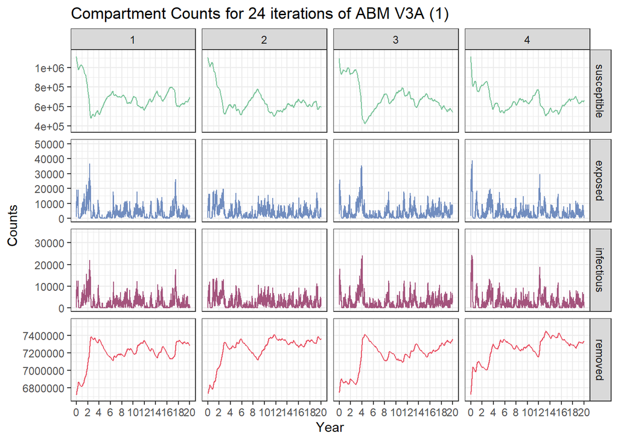

```r
ABM_V3A_experiments %>%
  filter(series != "notifications") %>%
  mutate(year = day/365) %>%
  ggplot() +
  geom_line(aes(x = year,y=value,color = series)) +
  facet_grid_paginate(series~experiment,scales = "free",ncol = 4,nrow = 4,page = 1) +
  theme_bw() +
  labs(title = "Compartment Counts for 24 iterations of ABM V3A (1)",x = "Year",y = "Counts") +
  scale_color_manual(values = c("#77c298","#718dbf","#a4547d","#e84d60")) +
  guides(colour = "none") +
  scale_x_continuous(breaks = 0:10*2)
```

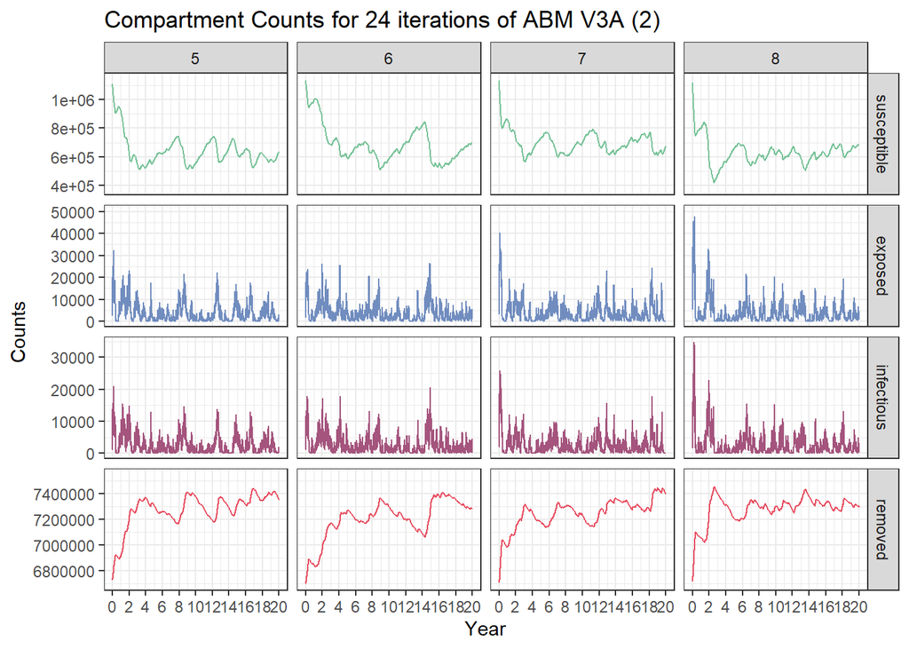

```r
ABM_V3A_experiments %>%
  filter(series != "notifications") %>%
  mutate(year = day/365) %>%
  ggplot() +
  geom_line(aes(x = year,y=value,color = series)) +
  facet_grid_paginate(series~experiment,scales = "free",ncol = 4,nrow = 4,page = 2) +
  theme_bw() +
  labs(title = "Compartment Counts for 24 iterations of ABM V3A (2)",x = "Year",y = "Counts") +
  scale_color_manual(values = c("#77c298","#718dbf","#a4547d","#e84d60")) +
  guides(colour = "none") +
  scale_x_continuous(breaks = 0:10*2)
```

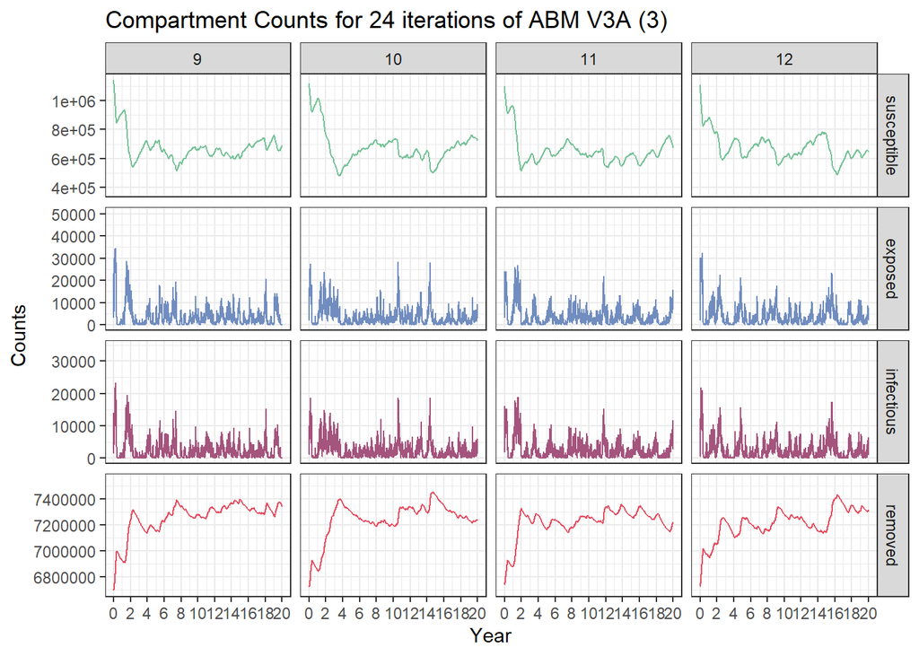

```r
ABM_V3A_experiments %>%
  filter(series != "notifications") %>%
  mutate(year = day/365) %>%
  ggplot() +
  geom_line(aes(x = year,y=value,color = series)) +
  facet_grid_paginate(series~experiment,scales = "free",ncol = 4,nrow = 4,page = 3) +
  theme_bw() +
  labs(title = "Compartment Counts for 24 iterations of ABM V3A (3)",x = "Year",y = "Counts") +
  scale_color_manual(values = c("#77c298","#718dbf","#a4547d","#e84d60")) +
  guides(colour = "none") +
  scale_x_continuous(breaks = 0:10*2)
```

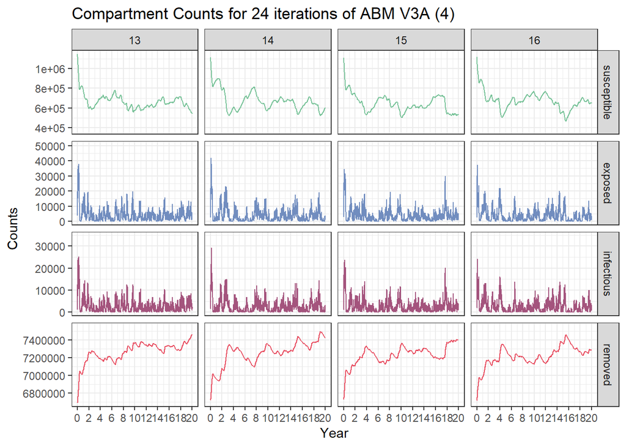

```r
ABM_V3A_experiments %>%
  filter(series != "notifications") %>%
  mutate(year = day/365) %>%
  ggplot() +
  geom_line(aes(x = year,y=value,color = series)) +
  facet_grid_paginate(series~experiment,scales = "free",ncol = 4,nrow = 4,page = 4) +
  theme_bw() +
  labs(title = "Compartment Counts for 24 iterations of ABM V3A (4)",x = "Year",y = "Counts") +
  scale_color_manual(values = c("#77c298","#718dbf","#a4547d","#e84d60")) +
  guides(colour = "none") +
  scale_x_continuous(breaks = 0:10*2)
```

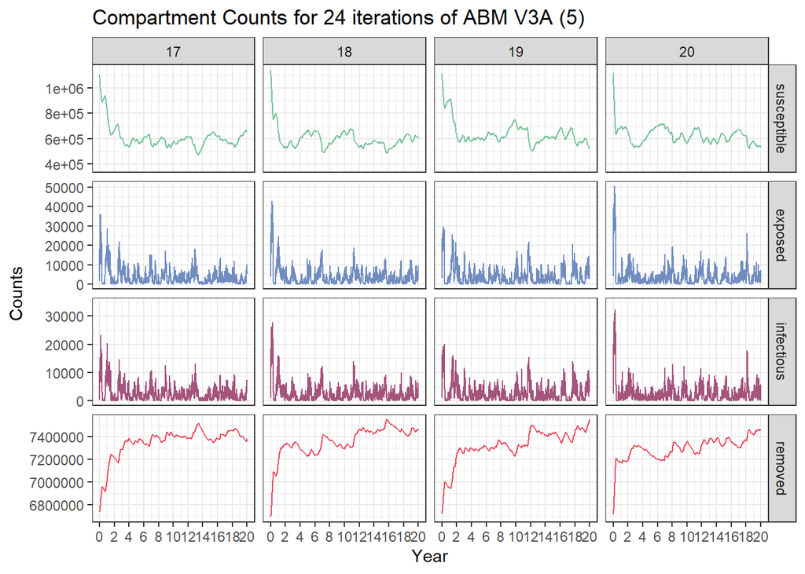

```r
ABM_V3A_experiments %>%
  filter(series != "notifications") %>%
  mutate(year = day/365) %>%
  ggplot() +
  geom_line(aes(x = year,y=value,color = series)) +
  facet_grid_paginate(series~experiment,scales = "free",ncol = 4,nrow = 4,page = 5) +
  theme_bw() +
  labs(title = "Compartment Counts for 24 iterations of ABM V3A (5)",x = "Year",y = "Counts") +
  scale_color_manual(values = c("#77c298","#718dbf","#a4547d","#e84d60")) +
  guides(colour = "none") +
  scale_x_continuous(breaks = 0:10*2)
```

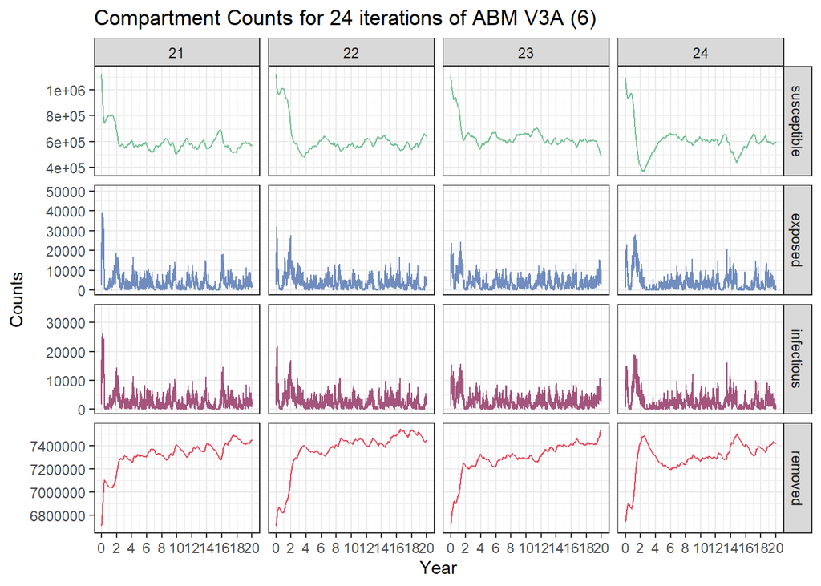

```r
ABM_V3A_experiments %>%
  filter(series != "notifications") %>%
  mutate(year = day/365) %>%
  ggplot() +
  geom_line(aes(x = year,y=value,color = series)) +
  facet_grid_paginate(series~experiment,scales = "free",ncol = 4,nrow = 4,page = 6) +
  theme_bw() +
  labs(title = "Compartment Counts for 24 iterations of ABM V3A (6)",x = "Year",y = "Counts") +
  scale_color_manual(values = c("#77c298","#718dbf","#a4547d","#e84d60")) +
  guides(colour = "none") +
  scale_x_continuous(breaks = 0:10*2)
```

Graphs of ABM V3A notification results:

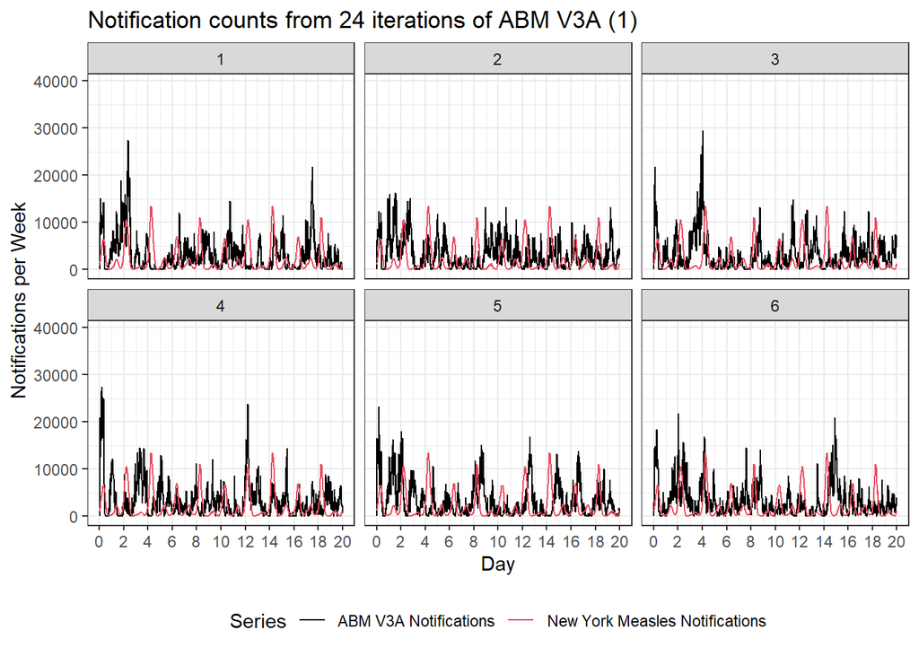

```r
ABM_V3A_experiments %>%
  filter(series == "notifications") %>%
  mutate(year = day/365) %>%
  ggplot() +
  geom_line(aes(x = year,y=value,color = "ABM V3A Notifications")) +
  geom_line(data = new_york_measles,aes(x = numdate-1940,y = cases/0.167,colour = "New York Measles Notifications")) +
  geom_line(data = new_york_measles,aes(x = numdate-1950,y = cases/0.167,colour = "New York Measles Notifications")) +
  facet_wrap_paginate(.~experiment,ncol = 3,nrow = 2,page = 1) +
  theme_bw() +
  labs(title = "Notification counts from 24 iterations of ABM V3A (1)",x = "Day",y = "Notifications per Week") +
  scale_x_continuous(breaks = 0:10*2) +
    scale_color_manual(values = c("black","#e84d60"),name = "Series") +
    theme(legend.position = "bottom")
```

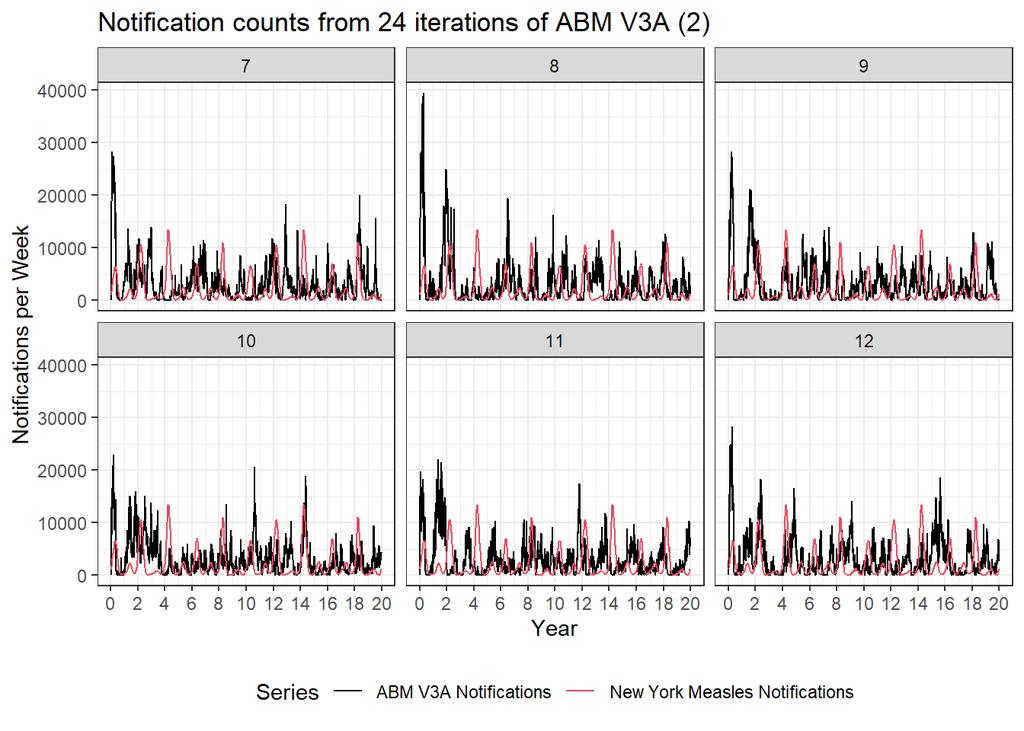

```r
ABM_V3A_experiments %>%
  filter(series == "notifications") %>%
  mutate(year = day/365) %>%
  ggplot() +
  geom_line(aes(x = year,y=value,color = "ABM V3A Notifications")) +
  facet_wrap_paginate(.~experiment,ncol = 3,nrow = 2,page=2) +
  geom_line(data = new_york_measles,aes(x = numdate-1940,y = cases/0.167,colour = "New York Measles Notifications")) +
  geom_line(data = new_york_measles,aes(x = numdate-1950,y = cases/0.167,colour = "New York Measles Notifications")) +
  theme_bw() +
  labs(title = "Notification counts from 24 iterations of ABM V3A (2)",x = "Year",y = "Notifications per Week") +
  scale_linetype_discrete(name = "") +
  scale_x_continuous(breaks = 0:10*2) +
    scale_color_manual(values = c("black","#e84d60"),name = "Series") +
    theme(legend.position = "bottom")
```

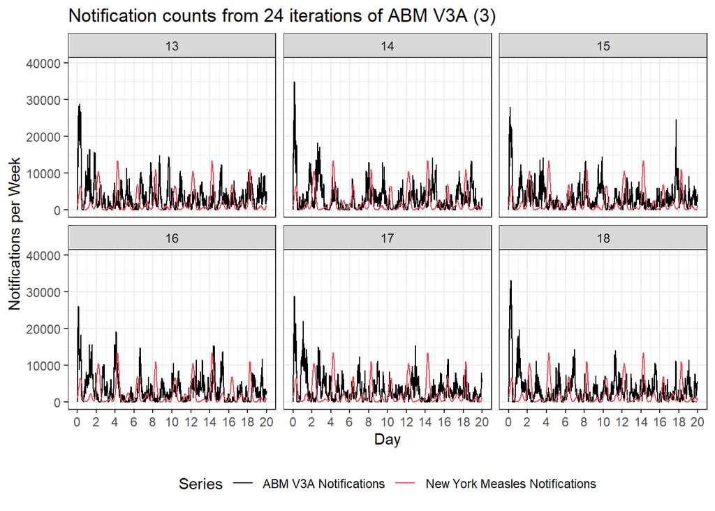

```r
ABM_V3A_experiments %>%
  filter(series == "notifications") %>%
  mutate(year = day/365) %>%
  ggplot() +
  geom_line(aes(x = year,y=value,color = "ABM V3A Notifications")) +
  geom_line(data = new_york_measles,aes(x = numdate-1940,y = cases/0.167,colour = "New York Measles Notifications")) +
  geom_line(data = new_york_measles,aes(x = numdate-1950,y = cases/0.167,colour = "New York Measles Notifications")) +
  facet_wrap_paginate(.~experiment,ncol = 3,nrow = 2,page = 3) +
  theme_bw() +
  labs(title = "Notification counts from 24 iterations of ABM V3A (3)",x = "Day",y = "Notifications per Week") +
  scale_x_continuous(breaks = 0:10*2) +
    scale_color_manual(values = c("black","#e84d60"),name = "Series") +
    theme(legend.position = "bottom")
```

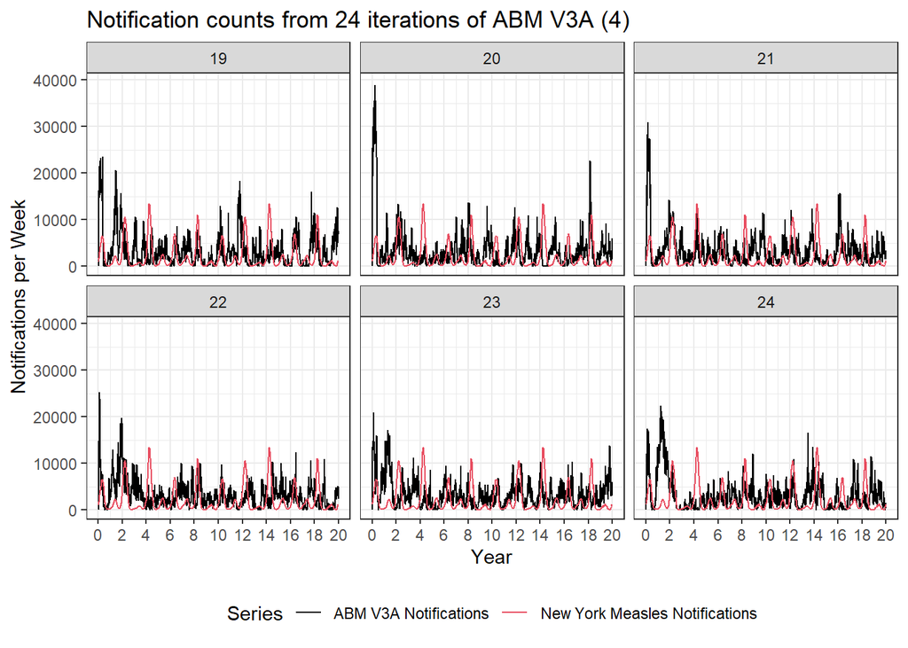

```r
ABM_V3A_experiments %>%
  filter(series == "notifications") %>%
  mutate(year = day/365) %>%
  ggplot() +
  geom_line(aes(x = year,y=value,color = "ABM V3A Notifications")) +
  facet_wrap_paginate(.~experiment,ncol = 3,nrow = 2,page=4) +
  geom_line(data = new_york_measles,aes(x = numdate-1940,y = cases/0.167,colour = "New York Measles Notifications")) +
  geom_line(data = new_york_measles,aes(x = numdate-1950,y = cases/0.167,colour = "New York Measles Notifications")) +
  theme_bw() +
  labs(title = "Notification counts from 24 iterations of ABM V3A (4)",x = "Year",y = "Notifications per Week") +
  scale_x_continuous(breaks = 0:10*2) +
    scale_color_manual(values = c("black","#e84d60"),name = "Series") +
    theme(legend.position = "bottom")
```

Max case histogram:

```r
max_cases_data <- new_york_measles %>%
  mutate(year = floor(numdate)) %>%
  group_by(year) %>%
  summarise(max_cases = max(cases)/0.167) %>%
  mutate(series = "New York Measles Cases 1950-1960")

max_cases_simulation <- ABM_V3A_experiments %>%
  mutate(year = floor(day/365)) %>%
  filter(year >= 10,series == "notifications")  %>%
  group_by(year,experiment) %>%
  summarise(max_cases = max(value)) %>%
  select(year,max_cases) %>%
  mutate(series = "ABM V3A")
```

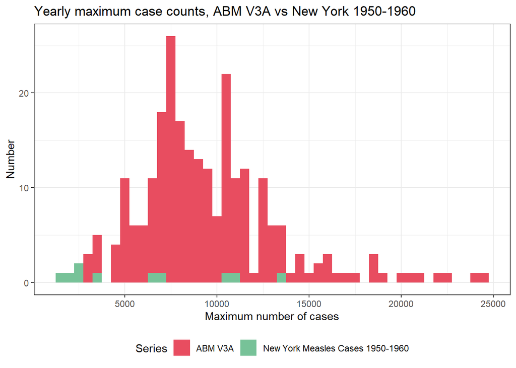

```r
rbind(max_cases_data,max_cases_simulation) %>%
  ggplot(aes(x = max_cases,fill = series)) +
  geom_histogram(binwidth = 500) +
  labs(title = "Yearly maximum case counts, ABM V3A vs New York 1950-1960",x = "Maximum number of cases",y = "Number") +
  scale_fill_manual(values = c("#e84d60","#77c298"),name = "Series") +
  theme_bw() +
  theme(legend.position = "bottom")
```

Mean observed max cases for high years and low years:

```r
max_cases_data %>%
  mutate(high_low = ifelse(year %% 2 == 0,"High","Low")) %>%
  group_by(high_low) %>%
  summarise(mean_max_cases = mean(max_cases))
```

| high_low | mean_max_cases |
| --- | --- |
| High | 9757.790 |
| Low | 2412.226 |

Histogram of total cases observed in a year:

```r
mean_cases_data <- new_york_measles %>%
  mutate(year = floor(numdate)) %>%
  group_by(year) %>%
  summarise(total_cases = sum(cases)/0.167) %>%
  mutate(series = "New York Measles Cases 1950-1960")

mean_cases_simulation <- ABM_V3A_experiments %>%
  mutate(year = floor(day/365)) %>%
  filter(year >= 10,series == "notifications")  %>%
  group_by(year,experiment) %>%
  summarise(total_cases = sum(value)) %>%
  select(year,total_cases) %>%
  mutate(series = "ABM V3A")
```

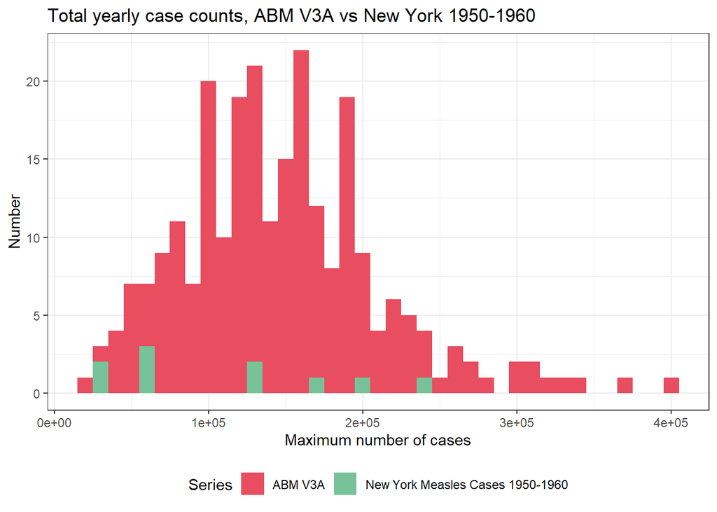

```r
rbind(mean_cases_data,mean_cases_simulation) %>%
  ggplot(aes(x = total_cases,fill = series)) +
  geom_histogram(binwidth = 10000) +
  labs(title = "Total yearly case counts, ABM V3A vs New York 1950-1960",x = "Maximum number of cases",y = "Number") +
  scale_fill_manual(values = c("#e84d60","#77c298"),name = "Series") +
  theme_bw() +
  theme(legend.position = "bottom")
```

Loading ABM V3B trial data:

```r
ABM_V3B_experiments <- read.csv("data/model08042021_seasonal_variationv3B.csv",
    skip = 33)
ABM_V3B_experiments[[1]] <- 1:dim(ABM_V3B_experiments)[1]
colnames(ABM_V3B_experiments)[1] <- "day"
ABM_V3B_experiments <- ABM_V3B_experiments %>%
  pivot_longer(2:dim(ABM_V3B_experiments)[2]) %>%
  mutate(experiment = str_extract(name,"\\d+$")) %>%
  mutate(experiment = if_else(is.na(experiment),1,as.integer(experiment)+1)) %>%
  mutate(series = str_extract(name,"with..\\w+")) %>%
  mutate(series = if_else(is.na(series),"notifications",substr(series,start=7,stop=nchar(series)))) %>%
  mutate(series = factor(series,levels = c("notifications","susceptible","exposed","infectious","removed"))) %>%
  mutate(value = value*7842545/27382)

ABM_V3B_experiments <- ABM_V3B_experiments %>%
  filter(series != "notifications" | (series == "notifications" & day %% 7 == 1))
```

Compartment count graphs for ABM V3B:

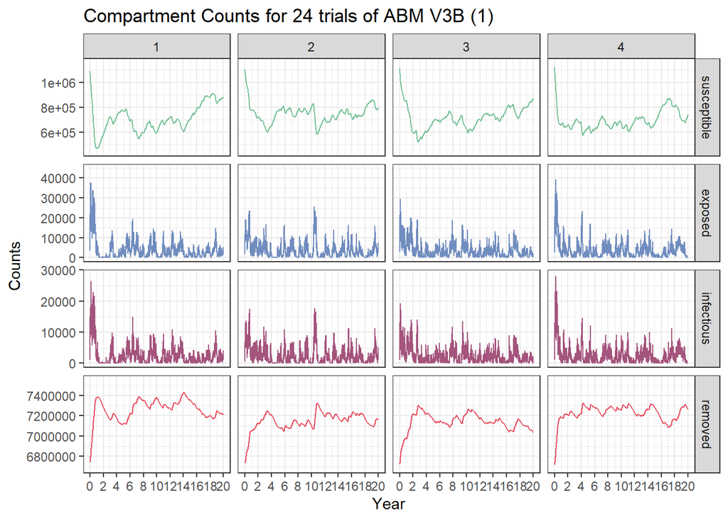

```r
ABM_V3B_experiments %>%
  filter(series != "notifications") %>%
  mutate(year = day/365) %>%
  ggplot() +
  geom_line(aes(x = year,y=value,color = series)) +
  facet_grid_paginate(series~experiment,scales = "free",ncol = 4,nrow = 4,page = 1) +
  theme_bw() +
  labs(title = "Compartment Counts for 24 trials of ABM V3B (1)",x = "Year",y = "Counts") +
  scale_color_manual(values = c("#77c298","#718dbf","#a4547d","#e84d60")) +
  guides(colour = "none") +
  scale_x_continuous(breaks = 0:10*2)
```

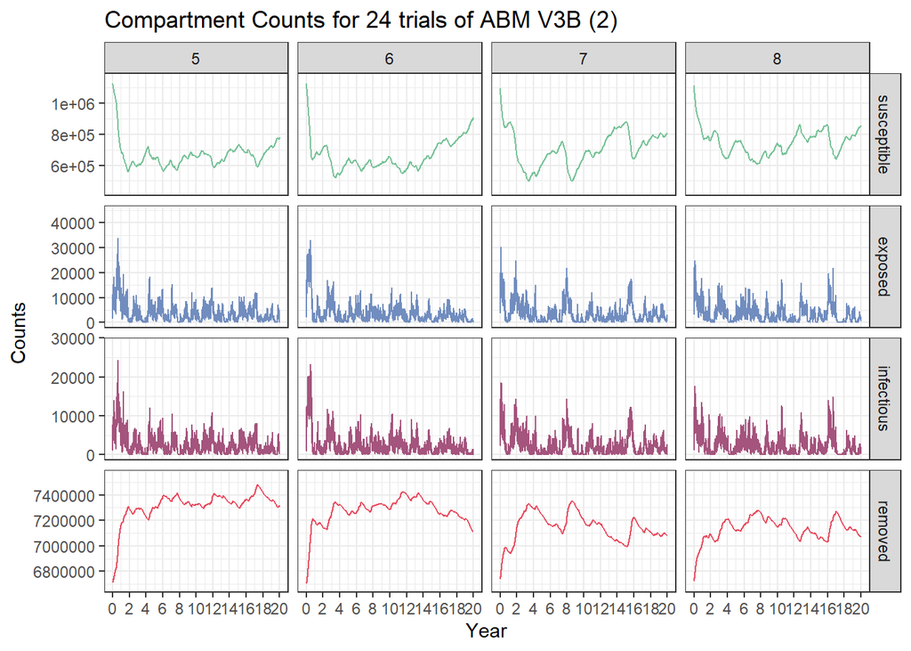

```r
ABM_V3B_experiments %>%
  filter(series != "notifications") %>%
  mutate(year = day/365) %>%
  ggplot() +
  geom_line(aes(x = year,y=value,color = series)) +
  facet_grid_paginate(series~experiment,scales = "free",ncol = 4,nrow = 4,page = 2) +
  theme_bw() +
  labs(title = "Compartment Counts for 24 trials of ABM V3B (2)",x = "Year",y = "Counts") +
  scale_color_manual(values = c("#77c298","#718dbf","#a4547d","#e84d60")) +
  guides(colour = "none") +
  scale_x_continuous(breaks = 0:10*2)
```

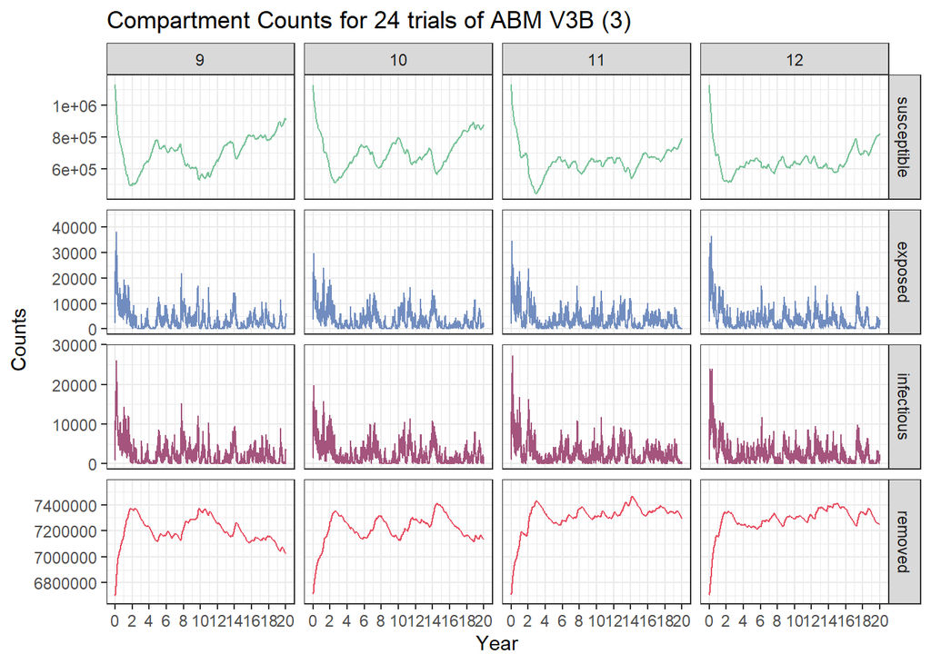

```r
ABM_V3B_experiments %>%
  filter(series != "notifications") %>%
  mutate(year = day/365) %>%
  ggplot() +
  geom_line(aes(x = year,y=value,color = series)) +
  facet_grid_paginate(series~experiment,scales = "free",ncol = 4,nrow = 4,page = 3) +
  theme_bw() +
  labs(title = "Compartment Counts for 24 trials of ABM V3B (3)",x = "Year",y = "Counts") +
  scale_color_manual(values = c("#77c298","#718dbf","#a4547d","#e84d60")) +
  guides(colour = "none") +
  scale_x_continuous(breaks = 0:10*2)
```

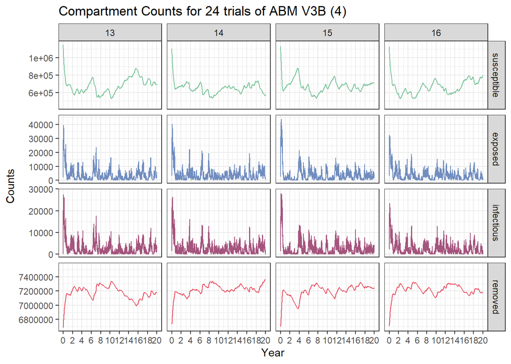

```r
ABM_V3B_experiments %>%
  filter(series != "notifications") %>%
  mutate(year = day/365) %>%
  ggplot() +
  geom_line(aes(x = year,y=value,color = series)) +
  facet_grid_paginate(series~experiment,scales = "free",ncol = 4,nrow = 4,page = 4) +
  theme_bw() +
  labs(title = "Compartment Counts for 24 trials of ABM V3B (4)",x = "Year",y = "Counts") +
  scale_color_manual(values = c("#77c298","#718dbf","#a4547d","#e84d60")) +
  guides(colour = "none") +
  scale_x_continuous(breaks = 0:10*2)
```

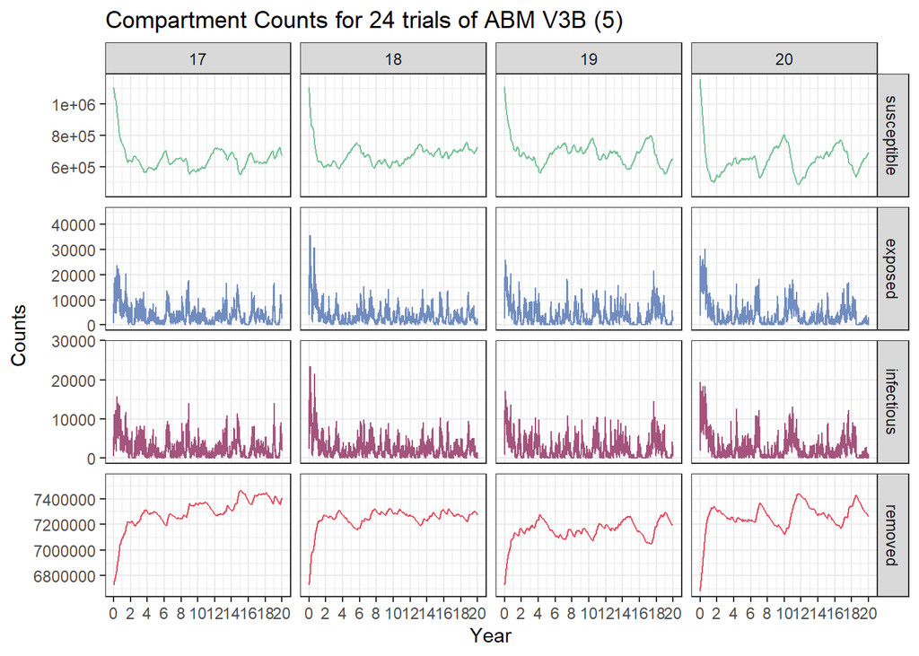

```r
ABM_V3B_experiments %>%
  filter(series != "notifications") %>%
  mutate(year = day/365) %>%
  ggplot() +
  geom_line(aes(x = year,y=value,color = series)) +
  facet_grid_paginate(series~experiment,scales = "free",ncol = 4,nrow = 4,page = 5) +
  theme_bw() +
  labs(title = "Compartment Counts for 24 trials of ABM V3B (5)",x = "Year",y = "Counts") +
  scale_color_manual(values = c("#77c298","#718dbf","#a4547d","#e84d60")) +
  guides(colour = "none") +
  scale_x_continuous(breaks = 0:10*2)
```

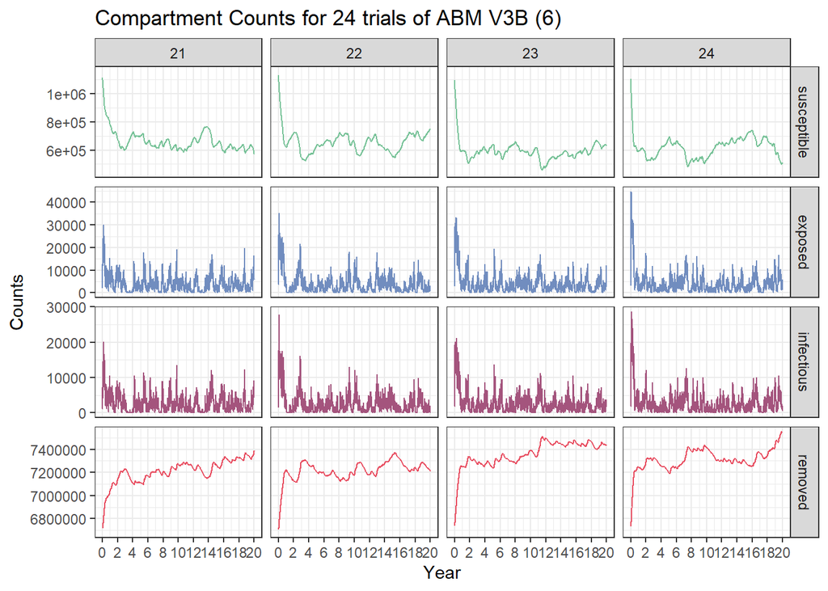

```r
ABM_V3B_experiments %>%
  filter(series != "notifications") %>%
  mutate(year = day/365) %>%
  ggplot() +
  geom_line(aes(x = year,y=value,color = series)) +
  facet_grid_paginate(series~experiment,scales = "free",ncol = 4,nrow = 4,page = 6) +
  theme_bw() +
  labs(title = "Compartment Counts for 24 trials of ABM V3B (6)",x = "Year",y = "Counts") +
  scale_color_manual(values = c("#77c298","#718dbf","#a4547d","#e84d60")) +
  guides(colour = "none") +
  scale_x_continuous(breaks = 0:10*2)
```